# Tutorial: Multilevel and Hierarchical Modeling (Part 2)

Chao-Yo Cheng  
7 March 2021

# 1 Introduction

By the end of today, you will know how to:

- Fit a (linear) multi-level model.
- Allow the intercepts and/or slopes to vary in a linear multi-level model.
- Inspect a linear multi-level model in line with model assumptions.

# 2 Packages

We will continue to use the same packages from the previous week. That is, we will use the `lme4` package, which includes a variety of functions to fit linear and non-linear multilevel models.

The `lme4` package does not report p-values in model summary tables (recall that there is some controversies around the use of p-values). If we want to report p-values for our models, we can supplement `lme4` with the `lmerTest` package.

Finally, we will use the `lattice` and `ggplot2` packages to visualize the results.

We will also need `dplyr` for data wrangling. Alternatively, you can load the `tidyverse` package.

```r
library(lme4) # for regression
library(lmerTest) # for p-value
library(lattice) # for visualization
library(ggplot2) # for visualization
library(tidyverse) # for data wrangling
```

# 3 Data

We will continue to analyze **World Values Survey (WVS)** today – one of the largest survey projects in about 100 countries. WVS started as the 1981 European Values Study (EVS) (led b Jan Kerkhofs and Ruud de Moory) and was later expanded under the leadership of Ronald Inglehart at the University of Michigan.

WVS “explores people’s values and beliefs, how they change over time, and what social and political impact they have.” For more information about WVS, click [here](https://www.worldvaluessurvey.org/wvs.jsp).

Today we will be studying Wave 7 (2017-2020). It is a huge dataset and includes variables from other cross-national political and socioeconomic datasets (e.g., [Varieties of Democracy](http://www.v-dem.net/)). You can find the complete codebook on Moodle along with other tutorial materials.

For the purpose of demonstration, we will focus on the following variables in this tutorial.

- `happy` (ordinal): Happiness; the variable ranges from 4 to 1; “4” means *very happy* and “1” means *not at all happy*.
- `edu` (ordinal): Highest educational level of the respondent; the variable ranges between 1 and 8, with 8 referring to the highest level of education (doctoral or equivalent). This will be our main **individual-level** predictor today. This variable is recoded based on `Q275` in the original dataset.
- `regime_type` (categorical): Regime type of the country. This variable is provided by the [Polity V](https://www.systemicpeace.org/polityproject.html) dataset. Each country is assigned into one of the following categories: Autocracy, closed anocracy, open anocracy, and democracy. Anocracy, by definition, refers to political regimes that exhibit both some democratic and autocratic charateristics. This will be our main **group-level** predictor today.

> *Question: How else can we group the respondents in the survey? And why?*

Let’s read in the data and take a look at the variables. We will use `readRDS()` to import the `.RData` file.

```r
dta <- readRDS("WVS_7.RData")
```

Now we can carry out some data wrangling.

```r
dta_new <- dta %>%
  dplyr::select(Q46P, Q275, regtype) %>%
  rename(edu = Q275) %>%
  mutate(Q46P = ifelse(Q46P <= 0, NA, Q46P),
         edu = ifelse(edu <= 0, NA, edu),
         regtype = ifelse(regtype <= 0, NA, regtype)) %>%
  mutate(regtype = as.character(regtype),
         Q46P = as.character(Q46P)) %>%
  mutate(happy = recode(Q46P,
                        "4" = "1",
                        "3" = "2",
                        "2" = "3",
                        "1" = "4"),
         reg_type = recode(regtype,
                           "5" = "full democracy",
                           "4" = "democracy",
                           "3" = "open anocracy",
                           "2" = "closed anocracy",
                           "1" = "autocracy")) %>%
  mutate(happy = as.numeric(happy)) %>%
  tidyr::drop_na(regtype, happy)
#table(dta_new$happy, dta_new$Q46P)
```

# 4 Analysis

|  | Formal expression |
| --- | --- |
| Linear (fixed $\alpha$ and $\beta$) | $Y=\alpha+\beta X+\epsilon$ |
| Linear Multilevel (varying $\alpha$ only) | $Y=\alpha_i+\beta X+\epsilon$ |
| Linear Multilevel (varying $\beta$ only) | $Y=\alpha+\beta_i X+\epsilon$ |
| Linear Multilevel (varying $\alpha$ and $\beta$ only) | $Y=\alpha_i+\beta_i X+\epsilon$ |

|  | `R` code |
| --- | --- |
| Linear (fixed $\alpha$ and $\beta$) | `lm(happy~edu)` |
| Linear Multilevel (varying $\alpha$) | `lmer(happy~edu+(1\|reg_type))` |
| Linear Multilevel (varying $\beta$) | `lmer(happy~edu+(0+edu\|reg_type))` |
| Linear Multilevel (varying $\alpha$ and $\beta$) | `lmer(happy~edu+(1+edu\|reg_type))` |

We will jump ahead to fit different (linear) multilevel models. Again, the outcome of interest ($Y$) is `happy` and the predictor ($X$) is `edu`; using `reg_type` as the *grouping* variable, we want to use linear multilevel model to answer the following question:

**How does the relationship between `edu` and `happy` vary by `reg_type`?**

As the starter, once again, let’s use our old friend `lm()` before we proceed.

```r
options(scipen=999)
mod_lm <- lm(happy ~ edu, data=dta_new)
summary(mod_lm)
```

```
##
## Call:
## lm(formula = happy ~ edu, data = dta_new)
##
## Residuals:
##     Min      1Q  Median      3Q     Max
## -0.8769 -0.8247  0.1440  0.1753  2.1962
##
## Coefficients:
##              Estimate Std. Error t value             Pr(>|t|)
## (Intercept)  1.887362   0.005949 317.268 < 0.0000000000000002 ***
## edu         -0.010445   0.001440  -7.252    0.000000000000416 ***
## ---
## Signif. codes:  0 '***' 0.001 '**' 0.01 '*' 0.05 '.' 0.1 ' ' 1
##
## Residual standard error: 0.7041 on 66645 degrees of freedom
##   (4597 observations deleted due to missingness)
## Multiple R-squared:  0.0007884,  Adjusted R-squared:  0.0007734
## F-statistic: 52.59 on 1 and 66645 DF,  p-value: 0.0000000000004163
```

There seems to be a **negative** correlation between `edu` and `happy` (huh?).

Now we will attempt several types of multilevel modeling approaches (using `reg_type` to group respondents across different countries), which can depend on several things.

- Should we include any predictors?
- Should we allow the intercept to vary by group?
- Should we allow the slope to vary by group?

> *Question: How do you make decisions on these questions?*

## 4.1 Varying Intercept and Fixed Slope

If we only allow the intercept to vary by group without including any predictor, basically we are trying to fit the following models in one go with `lmer()`:
$$\text{happy}=\alpha_i+\beta+\epsilon,$$
in which we use $i$ to denote a given regime type (e.g., autocracy, closed anocracy, open anocracy, democracy, full democracy).

Since we have five groups, that means our goal is to find the estimated intercept of each type (in other words, in total we want to have five $\alpha$s) while keeping the estimated slope the same regardless of the regime type.

Let’s fit the model.

```r
options(scipen=999)
mod_lmm_1 <- lmer(happy ~ edu + (1|reg_type), data=dta_new)
summary(mod_lmm_1)
```

```
## Linear mixed model fit by REML. t-tests use Satterthwaite's method [
## lmerModLmerTest]
## Formula: happy ~ edu + (1 | reg_type)
##    Data: dta_new
##
## REML criterion at convergence: 141903.7
##
## Scaled residuals:
##     Min      1Q  Median      3Q     Max
## -1.4556 -1.1413  0.1787  0.2844  3.2421
##
## Random effects:
##  Groups   Name        Variance Std.Dev.
##  reg_type (Intercept) 0.004908 0.07006
##  Residual             0.492007 0.70143
## Number of obs: 66647, groups:  reg_type, 5
##
## Fixed effects:
##                 Estimate   Std. Error           df t value             Pr(>|t|)
## (Intercept)     1.934526     0.031957     4.240032   60.53          0.000000217
## edu            -0.014921     0.001469 66554.205927  -10.16 < 0.0000000000000002
##
## (Intercept) ***
## edu         ***
## ---
## Signif. codes:  0 '***' 0.001 '**' 0.01 '*' 0.05 '.' 0.1 ' ' 1
##
## Correlation of Fixed Effects:
##     (Intr)
## edu -0.170
```

The regression output does not tell us the exact estimated intercept of each regime type, so we have to get them manually. To do so,

- Step 1: in the regression output, you can find the **average** of all estimated intercepts across political regimes listed under `Fixed effects`. You can use `fixef()` to obtain it. This is also known as the **fixed** part of the estimated intercept of each regime type.
- Step 2: Now we know the average, the question now is how far away each intercept is from the average. This is the **random** part of the estimated intercept of each regime type. We can use the function `ranef()` to call out them out.
- Step 3: The sum of `fixef()` and `ranef()` is the estimated intercept of each group (or regime type).

```r
fixef(mod_lmm_1) # fixed part of each intercept
```

```
## (Intercept)         edu
##  1.93452585 -0.01492113
```

```r
ranef(mod_lmm_1) # random part of each intercept
```

```
## $reg_type
##                 (Intercept)
## autocracy       -0.02037980
## closed anocracy -0.01512206
## democracy       -0.08924766
## full democracy   0.02338156
## open anocracy    0.10136795
##
## with conditional variances for "reg_type"
```

You can also plot the random part of each estimated intercept, with the confidence interval included for each of them.

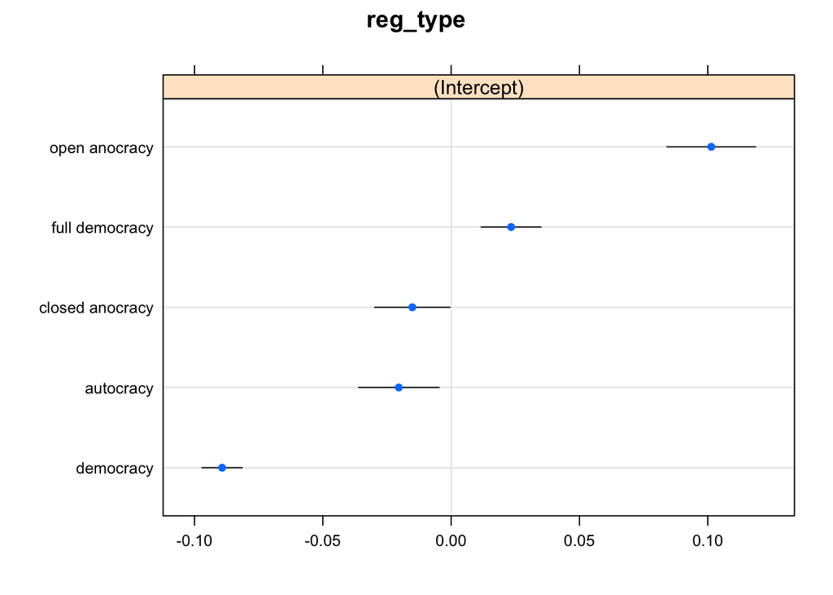

```r
dotplot(ranef(mod_lmm_1, condVar = TRUE))
```

Alternatively, We can use the `coef()` function again to extract the estimated intercept of each regime type – this is a good way to double check your calculation (or skip the calculation).

```r
coef(mod_lmm_1)
```

```
## $reg_type
##                 (Intercept)         edu
## autocracy          1.914146 -0.01492113
## closed anocracy    1.919404 -0.01492113
## democracy          1.845278 -0.01492113
## full democracy     1.957907 -0.01492113
## open anocracy      2.035894 -0.01492113
##
## attr(,"class")
## [1] "coef.mer"
```

## 4.2 Fixed Intercept and Varying Slope

Say now we believe that the intercept for each regime type should be the same, but each regime type will have a different slope. This idea will turn our model into:
$$\text{happy}=\alpha+\beta_i(\text{edu})+\epsilon.$$
Our objective is to find the estimated slope corresponding to each regime type.

```r
options(scipen=999)
mod_lmm_2 <- lmer(happy ~ edu + (0+edu|reg_type), data=dta_new)
```

And we can study the results as above.

Likewise, the regression output does not tell us the exact estimated slope of each regime type, so we have to get them manually.

- Step 1: in the regression output, you can find the **average** of all estimated slopes across political regimes listed under `Fixed effects`. You can use `fixef()` to obtain it. This is also known as the **fixed** part of the estimated slope of each regime type.
- Step 2: Now we know the average, the question now is how far away each slope is from the mean. This is the **random** part of the estimated slope of each regime type. We can use the function `ranef()` to call out them out.
- Step 3: The sum of `fixef()` and `ranef()` is the estimated slope of each group (or regime type).

```r
fixef(mod_lmm_2) # fixed part of each slope
```

```
##  (Intercept)          edu
##  1.896795217 -0.006546253
```

```r
ranef(mod_lmm_2) # random part of each slope
```

```
## $reg_type
##                           edu
## autocracy        0.0036402329
## closed anocracy -0.0048329364
## democracy       -0.0198540957
## full democracy   0.0009217795
## open anocracy    0.0201250197
##
## with conditional variances for "reg_type"
```

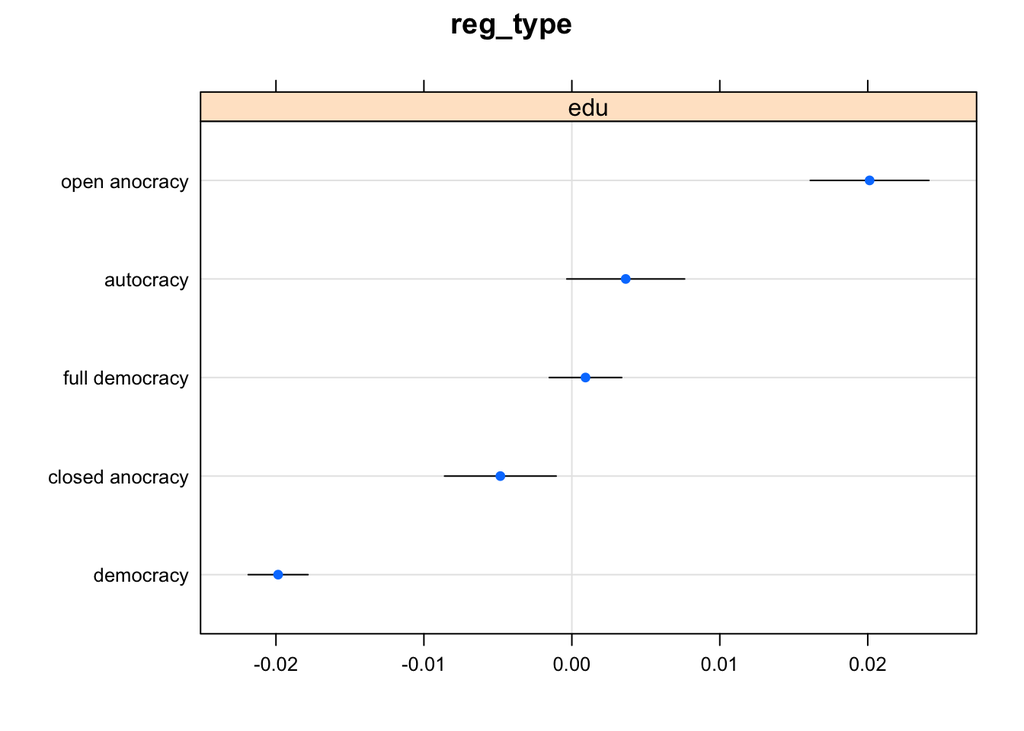

```r
dotplot(ranef(mod_lmm_2, condVar = TRUE))
```

```r
coef(mod_lmm_2)
```

```
## $reg_type
##                 (Intercept)          edu
## autocracy          1.896795 -0.002906020
## closed anocracy    1.896795 -0.011379189
## democracy          1.896795 -0.026400348
## full democracy     1.896795 -0.005624473
## open anocracy      1.896795  0.013578767
##
## attr(,"class")
## [1] "coef.mer"
```

## 4.3 Varying Intercept and Slope

Finally, if we decide that each regime type should have its own unique intercept and slope, then the model becomes:
$$\text{happy}=\alpha_i+\beta_i(\text{edu})+\epsilon.$$
Our objective is to find the estimated intercept and slope corresponding to each regime type.

```r
options(scipen=999)
mod_lmm_3 <- lmer(happy ~ edu + (1+edu|reg_type), data=dta_new)
```

Again, we can study the results as above.

```r
fixef(mod_lmm_3) # fixed part of each intercept and slope
```

```
## (Intercept)         edu
##  1.93130079 -0.01294151
```

```r
ranef(mod_lmm_3) # random part of each intercept and slope
```

```
## $reg_type
##                  (Intercept)          edu
## autocracy       -0.136701855  0.032581235
## closed anocracy  0.008282976 -0.007920157
## democracy       -0.088932747 -0.001125481
## full democracy   0.108446755 -0.020451313
## open anocracy    0.108904870 -0.003084284
##
## with conditional variances for "reg_type"
```

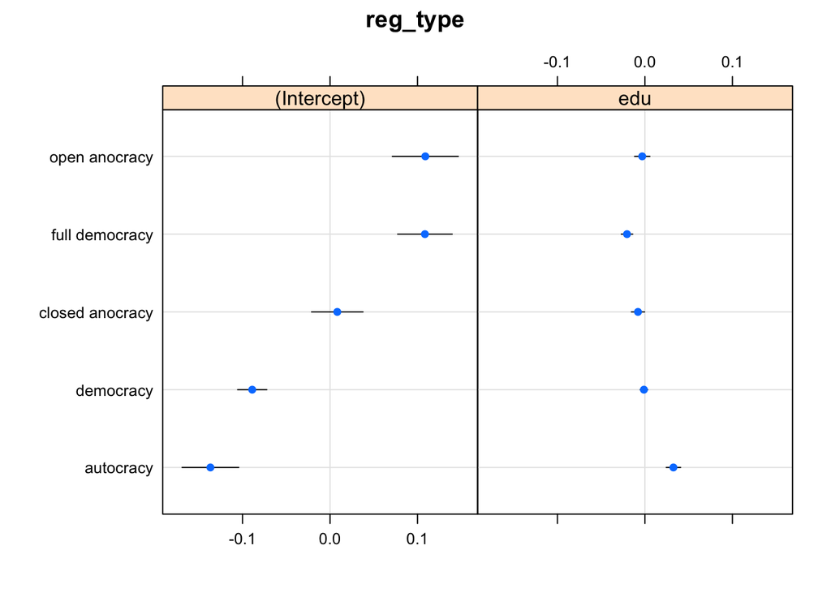

```r
dotplot(ranef(mod_lmm_3, condVar = TRUE))
```

```r
coef(mod_lmm_3)
```

```
## $reg_type
##                 (Intercept)         edu
## autocracy          1.794599  0.01963973
## closed anocracy    1.939584 -0.02086167
## democracy          1.842368 -0.01406699
## full democracy     2.039748 -0.03339282
## open anocracy      2.040206 -0.01602579
##
## attr(,"class")
## [1] "coef.mer"
```

# 5 Confidence Intervals

```r
mod_lmm_1 <- lmer(happy ~ edu + (1|reg_type), data=dta_new)
mod_lmm_2 <- lmer(happy ~ edu + (0+edu|reg_type), data=dta_new)
mod_lmm_3 <- lmer(happy ~ edu + (1+edu|reg_type), data=dta_new)
```

Let’s start with `mod_lmm_1` (varying intercept and fixed slope) – for the purpose of demonstration, I will explain the process step by step.

- Step 1: Obtain the average of all estimated intercepts using `fixef()`.
- Step 2: Obtain the random part of each estimated intercept using `ranef()`.
- Step 3: Turn `ranef()` into a `tibble` object; calculate the 95% confidence interval of each estimated intercept by taking into the account (1) the standard error of each random component and (2) the average of all estimated intercepts.

```r
res_lmm_1_fix <- fixef(mod_lmm_1)[1]
res_lmm_1_ran <- ranef(mod_lmm_1, condVar = TRUE)
res_lmm_1_ran_dd <- as_tibble(res_lmm_1_ran) %>%
  mutate(lwr = condval - 1.96*condsd + res_lmm_1_fix,
         upr = condval + 1.96*condsd + res_lmm_1_fix)
res_lmm_1_ran_dd
```

And proceed to check the estimated intercepts and slopes of `mod_lmm_2` (fixed intercept and varying slopes).

- Step 1: Obtain the average of all estimated slopes using `fixef()`.
- Step 2: Obtain the random part of each estimated slope using `ranef()`.
- Step 3: Turn `ranef()` into a `tibble` object; calculate the 95% confidence interval of each estimated slope by taking into the account (1) the standard error of each random part and (2) the average of all estimated slopes.

```r
res_lmm_2_fix <- fixef(mod_lmm_1)[2]
res_lmm_2_ran <- ranef(mod_lmm_1, condVar = TRUE)
res_lmm_2_ran_dd <- as_tibble(res_lmm_2_ran) %>%
  mutate(lwr = condval - 1.96*condsd + res_lmm_2_fix,
         upr = condval + 1.96*condsd + res_lmm_2_fix)
res_lmm_2_ran_dd
```

Below is the step you need for `res_lmm_3` (varying intercepts and slopes). Note that we have to work on the intercepts and slopes separately. Let’s start with the intercepts.

```r
res_lmm_3_fix <- fixef(mod_lmm_3)
res_lmm_3_ran <- ranef(mod_lmm_3, condVar = TRUE)
```

The intercepts:

```r
res_lmm_3_ran_dd <- as_tibble(res_lmm_3_ran) %>%
  filter(term == "(Intercept)") %>%
  mutate(lwr = condval - 1.96*condsd + res_lmm_3_fix[1],
         upr = condval + 1.96*condsd + res_lmm_3_fix[1])
res_lmm_3_ran_dd
```

The slopes:

```r
res_lmm_3_ran_dd <- as_tibble(res_lmm_3_ran) %>%
  filter(term == "edu") %>%
  mutate(lwr = condval - 1.96*condsd + res_lmm_3_fix[2],
         upr = condval + 1.96*condsd + res_lmm_3_fix[2])
res_lmm_3_ran_dd
```

# 6 Extra: Model Comparison and Diagnostics

## 6.1 Model Comparison

To compare the fits across different models, you can first use `anova()`. We do not cover maximum likelihood estimation (MLE) in IQSR, but AIC, BIC, log-likelihood, and deviance are all typical metrics we use to evaluate model fit when we use MLE to fit GLMs. For practical purposes, you can find that `mod_lmm_3` significantly improves model fit based on the data we have.

```r
anova(mod_lmm_1, mod_lmm_2, mod_lmm_3)
```

```
## Data: dta_new
## Models:
## mod_lmm_1: happy ~ edu + (1 | reg_type)
## mod_lmm_2: happy ~ edu + (0 + edu | reg_type)
## mod_lmm_3: happy ~ edu + (1 + edu | reg_type)
##           npar    AIC    BIC logLik deviance  Chisq Df            Pr(>Chisq)
## mod_lmm_1    4 141895 141932 -70944   141887
## mod_lmm_2    4 142014 142050 -71003   142006   0.00  0
## mod_lmm_3    6 141815 141870 -70901   141803 202.83  2 < 0.00000000000000022
##
## mod_lmm_1
## mod_lmm_2
## mod_lmm_3 ***
## ---
## Signif. codes:  0 '***' 0.001 '**' 0.01 '*' 0.05 '.' 0.1 ' ' 1
```

But we can use other statistical metrics to assess model fit, too, using what you have learned in Term 1 – the sum of squared residuals (SSR) and the R-squared. The first metric basically allows us to gauge the size of errors produced by the models and the second metric shows how much of the variance of $Y$ has been explained by the models we fit.

### 6.1.1 Sum of Squared Residuals

We can call the residuals of each model by using `names()` to unpack the objects produced by `lm()` and `lmer()` and call out the residuals using the `$` sign. Or we can just use the `resid()` function.

```r
lm_error <- resid(mod_lm)
sum(lm_error^2)
```

```
## [1] 33042.82
```

For `lmer()`, since the estimation was carried out by MLE, we can use the original formula (i.e., the difference between observed and predicted $Y$) to derive the residuals.

```r
lmm_error_1 <- resid(mod_lmm_1)
lmm_error_2 <- resid(mod_lmm_2)
lmm_error_3 <- resid(mod_lmm_3)
sum(lmm_error_1^2)
```

```
## [1] 32787.87
```

```r
sum(lmm_error_2^2)
```

```
## [1] 32846.93
```

```r
sum(lmm_error_3^2)
```

```
## [1] 32736
```

Interestingly, multilevel modeling may produce slightly better predictions.

### 6.1.2 R-Squared

R-squared is defined by the ratio of the variance of predicted $Y$ (i.e., $\text{var}(\widehat{Y})$) and the variance of observed $Y$ (i.e., $\text{var}(Y)$). We can first derive the variance of observed $Y$ by

```r
var_y <- var(dta_new$happy, na.rm=T)
```

Next, let’s get the variance of $\text{var}(\widehat{Y})$ produced by different models. You can extract the fitted values directly or use the `predict()` function.

```r
var_y_hat_lm <- var(predict(mod_lm), na.rm=T)
var_y_hat_lmm_1 <- var(predict(mod_lmm_1), na.rm=T)
var_y_hat_lmm_2 <- var(predict(mod_lmm_2), na.rm=T)
var_y_hat_lmm_3 <- var(predict(mod_lmm_3), na.rm=T)
```

Then we can calculate the respective R-squared of each model.

```r
var_y_hat_lm/var_y
```

```
## [1] 0.0007738819
```

```r
var_y_hat_lmm_1/var_y
```

```
## [1] 0.008225723
```

```r
var_y_hat_lmm_2/var_y
```

```
## [1] 0.00647283
```

```r
var_y_hat_lmm_3/var_y
```

```
## [1] 0.009653281
```

The multilevel models do not perform too differently, but `mod_lmm_3` seems the best.

*Question: How do you make the choice?*

*Question: Try calculate the R-squared by political regime and report your observations.*

## 6.2 Residuals

First, let’s call out the residuals of all `lm()` and `lmer()` models. You can use the `resid()`, but we can actually find the residuals or errors using the `$` sign.

```r
error_lm <- resid(mod_lm)
error_lmm_1 <- resid(mod_lmm_1)
error_lmm_2 <- resid(mod_lmm_2)
error_lmm_3 <- resid(mod_lmm_3)
```

Let’s do a quick summary statistics for each of them.

```r
summary(error_lm)
```

```
##    Min. 1st Qu.  Median    Mean 3rd Qu.    Max.
## -0.8769 -0.8247  0.1440  0.0000  0.1753  2.1962
```

```r
summary(error_lmm_1)
```

```
##    Min. 1st Qu.  Median    Mean 3rd Qu.    Max.
## -1.0210 -0.8005  0.1254  0.0000  0.1995  2.2741
```

```r
summary(error_lmm_2)
```

```
##    Min. 1st Qu.  Median    Mean 3rd Qu.    Max.
## -1.0054 -0.8171  0.1257  0.0000  0.1824  2.3144
```

```r
summary(error_lmm_3)
```

```
##    Min. 1st Qu.  Median    Mean 3rd Qu.    Max.
## -1.0242 -0.7936  0.1268  0.0000  0.1998  2.2702
```

### 6.2.1 Normally Distributed Errors

> Question: What are some of the most important properties of a normal distribution?

We can first check whether the errors are distributed normally.

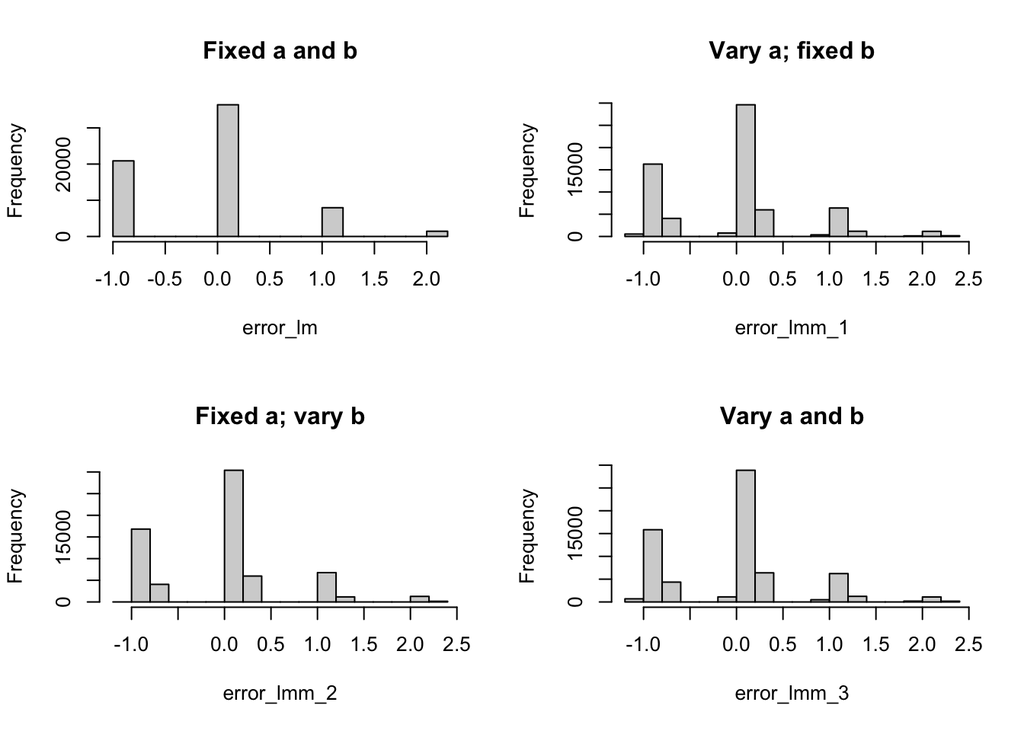

```r
par(mfrow=c(2,2))
hist(error_lm, main="Fixed a and b")
hist(error_lmm_1, main="Vary a; fixed b")
hist(error_lmm_2, main="Fixed a; vary b")
hist(error_lmm_3, main="Vary a and b")
```

Using **qq-plot** is probably a better idea.

```r
library(car)
par(mfrow=c(2,2))
qqPlot(error_lm, main="Fixed a and b")
```

```
##  649 1569
##  618 1430
```

```r
qqPlot(error_lmm_1, main="Vary a; fixed b")
```

```
##  1569 57906
##  1430 49557
```

```r
qqPlot(error_lmm_2, main="Fixed a; vary b")
```

```
##  1569 57906
##  1430 49557
```

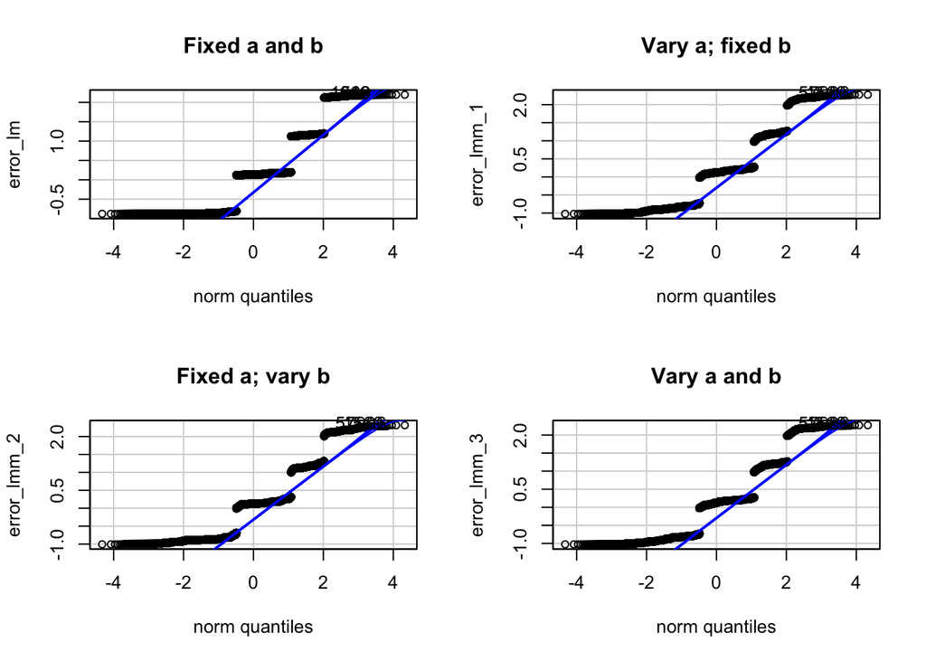

```
##  1569 57906
##  1430 49557
```

```r
qqPlot(error_lmm_3, main="Vary a and b")
```

### 6.2.2 Residuals and Predicted $Y$

You can also create the scatterplots, using the predicted $Y$ (i.e., $\widehat{Y}$) against the residuals (i.e., $\epsilon$); ideally, we should not observe any systematic patterns, which means

- $\widehat{Y}$ cannot predict $\epsilon$, OR
- $\widehat{Y}$ is not correlated with predict $\epsilon$).

```r
par(mfrow=c(2,2))
plot(resid(mod_lm) ~ predict(mod_lm), main="Fixed a and b")
plot(resid(mod_lmm_1) ~ predict(mod_lmm_1), main="Vary a; fixed b")
plot(resid(mod_lmm_2) ~ predict(mod_lmm_2), main="Fixed a; vary b")
plot(resid(mod_lmm_3) ~ predict(mod_lmm_3), main="Vary a and b")
```

You can also just check the correlation using `lm()` – again, ideally, they should **NOT** correlated with each other, so all estimated slopes should be statistically insignificant.

```r
summary(lm(resid(mod_lm) ~ predict(mod_lm)))
```

```
##
## Call:
## lm(formula = resid(mod_lm) ~ predict(mod_lm))
##
## Residuals:
##     Min      1Q  Median      3Q     Max
## -0.8769 -0.8247  0.1440  0.1753  2.1962
##
## Coefficients:
##                           Estimate         Std. Error t value Pr(>|t|)
## (Intercept)      0.000000000002802  0.254995972399403       0        1
## predict(mod_lm) -0.000000000001516  0.137900418444006       0        1
##
## Residual standard error: 0.7041 on 66645 degrees of freedom
## Multiple R-squared:  2.076e-27,  Adjusted R-squared:  -1.5e-05
## F-statistic: 1.384e-22 on 1 and 66645 DF,  p-value: 1
```

```r
summary(lm(resid(mod_lmm_1) ~ predict(mod_lmm_1)))
```

```
##
## Call:
## lm(formula = resid(mod_lmm_1) ~ predict(mod_lmm_1))
##
## Residuals:
##     Min      1Q  Median      3Q     Max
## -1.0222 -0.8002  0.1252  0.1998  2.2750
##
## Coefficients:
##                     Estimate Std. Error t value Pr(>|t|)
## (Intercept)        -0.012997   0.077954  -0.167    0.868
## predict(mod_lmm_1)  0.007029   0.042134   0.167    0.868
##
## Residual standard error: 0.7014 on 66645 degrees of freedom
## Multiple R-squared:  4.176e-07,  Adjusted R-squared:  -1.459e-05
## F-statistic: 0.02783 on 1 and 66645 DF,  p-value: 0.8675
```

```r
summary(lm(resid(mod_lmm_2) ~ predict(mod_lmm_2)))
```

```
##
## Call:
## lm(formula = resid(mod_lmm_2) ~ predict(mod_lmm_2))
##
## Residuals:
##     Min      1Q  Median      3Q     Max
## -1.0068 -0.8169  0.1255  0.1827  2.3159
##
## Coefficients:
##                     Estimate Std. Error t value Pr(>|t|)
## (Intercept)        -0.016485   0.087946  -0.187    0.851
## predict(mod_lmm_2)  0.008916   0.047541   0.188    0.851
##
## Residual standard error: 0.702 on 66645 degrees of freedom
## Multiple R-squared:  5.277e-07,  Adjusted R-squared:  -1.448e-05
## F-statistic: 0.03517 on 1 and 66645 DF,  p-value: 0.8512
```

```r
summary(lm(resid(mod_lmm_3) ~ predict(mod_lmm_3)))
```

```
##
## Call:
## lm(formula = resid(mod_lmm_3) ~ predict(mod_lmm_3))
##
## Residuals:
##     Min      1Q  Median      3Q     Max
## -1.0263 -0.7929  0.1266  0.2004  2.2716
##
## Coefficients:
##                    Estimate Std. Error t value Pr(>|t|)
## (Intercept)        -0.02181    0.07191  -0.303    0.762
## predict(mod_lmm_3)  0.01179    0.03886   0.303    0.762
##
## Residual standard error: 0.7009 on 66645 degrees of freedom
## Multiple R-squared:  1.382e-06,  Adjusted R-squared:  -1.362e-05
## F-statistic: 0.09209 on 1 and 66645 DF,  p-value: 0.7615
```

## 6.3 Random Effects

Here, we use **random effects** to refer to the random component of the estimated varying intercepts and/or slopes (depending on which model we are talking about).

We will use `mod_lmm_3` (varying intercept and slope) to demonstrate. We will use `ranef()` to extract the random component first.

```r
ran_eff <- ranef(mod_lmm_3)$reg_type
shapiro.test(ran_eff$"(Intercept)")
shapiro.test(ran_eff$"edu")
```